# Tugas Pertemuan 6

Joe Anthonie Oktavian

2026-10-01

## Packages

```r
library(ggplot2)
library(tsibble)
library(tseries)
library(MASS)
library(forecast)
library(TSA)
library(TTR)
library(aTSA)
library(graphics)
library(readxl)
```

## Load Data

```r
# Import data dari sheet 'Monthly'
data <- read_excel("C:/Users/santo/Downloads/CES9093161101.xlsx", sheet = "Monthly")

# Cek struktur data
str(data)
```

```
## tibble [852 × 3] (S3: tbl_df/tbl/data.frame)
##  $ observation_date: POSIXct[1:852], format: "1955-01-01" "1955-02-01" ...
##  $ Period          : num [1:852] 1 2 3 4 5 6 7 8 9 10 ...
##  $ CES9093161101   : num [1:852] 1707 1712 1725 1736 1745 ...
```

```r
head(data)
```

```
## # A tibble: 6 × 3
##   observation_date    Period CES9093161101
##   <dttm>               <dbl>         <dbl>
## 1 1955-01-01 00:00:00      1         1707.
## 2 1955-02-01 00:00:00      2         1712.
## 3 1955-03-01 00:00:00      3         1725.
## 4 1955-04-01 00:00:00      4         1736.
## 5 1955-05-01 00:00:00      5         1745.
## 6 1955-06-01 00:00:00      6         1787.
```

### Jadikan objek time series

```r
#Konversi kolom data menjadi objek time series (Mulai Jan 1955, frekuensi bulanan = 12)
data.ts <- ts(data$CES9093161101, start = c(1955, 1), frequency = 12)
```

## Eksplorasi Data

### Plot Data Penuh

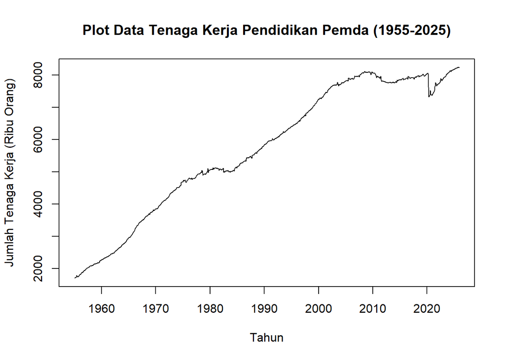

```r
plot.ts(data.ts,
        lty = 1,
        xlab = "Tahun",
        ylab = "Jumlah Tenaga Kerja (Ribu Orang)",
        main = "Plot Data Tenaga Kerja Pendidikan Pemda (1955-2025)")
```

Berdasarkan plot time series, terlihat bahwa data jumlah tenaga kerja memiliki pola tren naik, sehingga perlu diperiksa menggunakan uji formal apakah data tersebut stasioner.

## Pembagian Data dan Plotnya

### Data Latih dan Data Uji

```r
# 1. Data Latih (Jan 1955 - Des 2022) -> 816 observasi
train.ts <- window(data.ts, end = c(2022, 12))

# 2. Data Uji (Jan 2023 - Des 2025) -> 36 observasi
test.ts <- window(data.ts, start = c(2023, 1))

# Cek jumlah data masing-masing
length(train.ts) # Output: 816
```

```
## [1] 816
```

```r
length(test.ts)  # Output: 36
```

```
## [1] 36
```

### Plot Data Latih

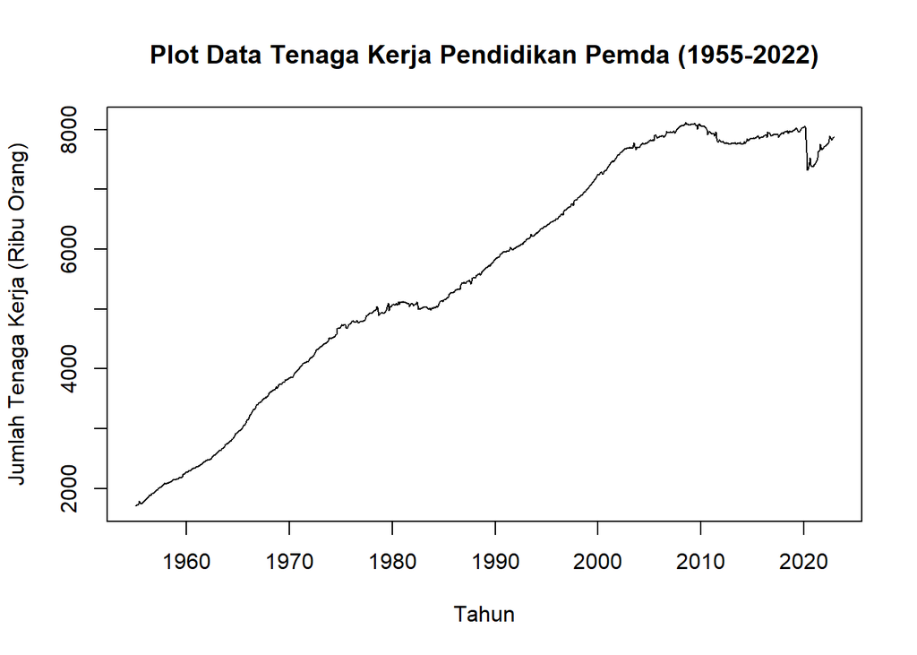

```r
plot.ts(train.ts,
        lty = 1,
        xlab = "Tahun",
        ylab = "Jumlah Tenaga Kerja (Ribu Orang)",
        main = "Plot Data Tenaga Kerja Pendidikan Pemda (1955-2022)")
```

Berdasarkan plot time series pada data latih, terlihat bahwa data jumlah tenaga kerja memiliki pola tren naik, sehingga perlu diperiksa menggunakan uji formal apakah data tersebut stasioner.

### Plot Data Uji

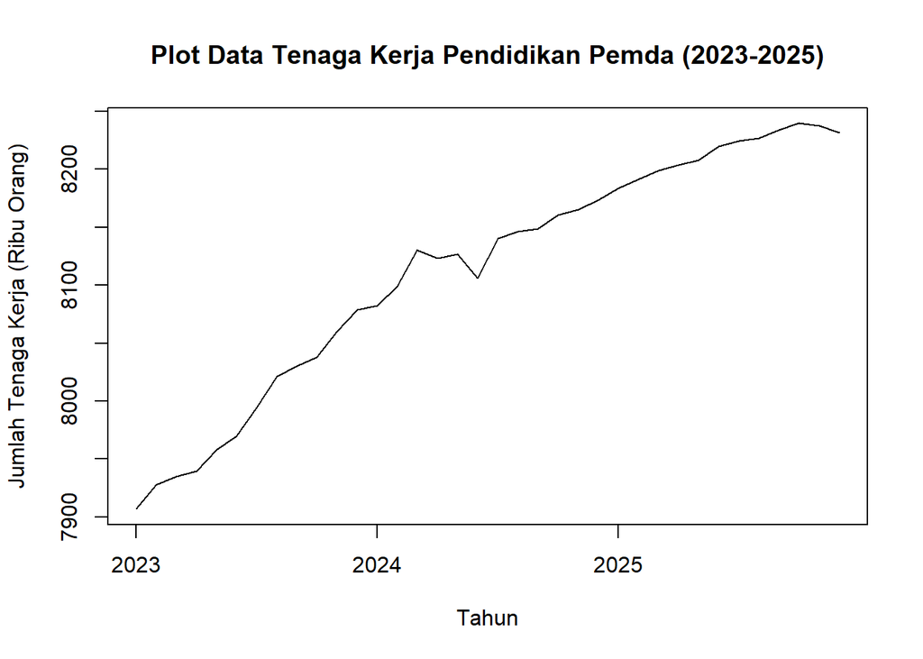

```r
# 1. Plot tanpa sumbu X bawaan (xaxt = "n")
plot.ts(test.ts,
        lty = 1,
        xaxt = "n",
        xlab = "Tahun",
        ylab = "Jumlah Tenaga Kerja (Ribu Orang)",
        main = "Plot Data Tenaga Kerja Pendidikan Pemda (2023-2025)")

# 2. Tambahkan sumbu X manual dengan label tahun bulat
axis(1, at = c(2023, 2024, 2025), labels = c("2023", "2024", "2025"))
```

## Pemeriksaan Stasioneritas Data

### Stasioner dalam Rataan

#### Plot ACF

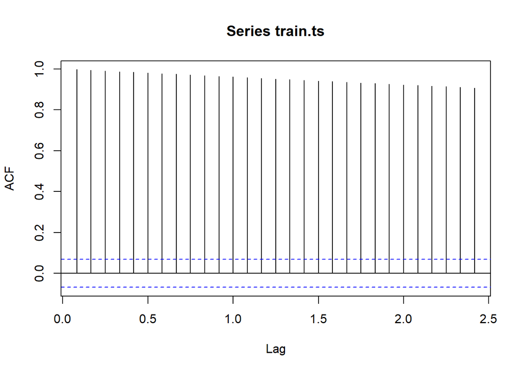

```r
acf(train.ts)
```

Berdasarkan plot ACF, terlihat bahwa data latih memiliki nilai ACF yang menurun lambat. Hal ini mengindikasikan data tidak stasioner dalam rataan. Akan tetapi, hasil ini perlu diverifikasi menggunakna uji formal.

#### Uji ADF

Untuk memeriksa apakah data latih telah stasioner dalam rata-rata, dilakukan uji formal **Augmented Dickey-Fuller (ADF)** dengan hipotesis sebagai berikut:

- $H_0$ : Data memiliki akar unit / *unit root* (Data **tidak stasioner**).
- $H_1$ : Data tidak memiliki akar unit / *unit root* (Data **stasioner**).

**Tingkat Signifikansi (**$\alpha$): 0,05 (5%)

**Kriteria Pengambilan Keputusan:** * Jika $p\text{-value} < \alpha$ ($0,05$), maka **Tolak** $H_0$ (Data stasioner). * Jika $p\text{-value} \ge \alpha$ ($0,05$), maka **Gagal Tolak** $H_0$ (Data tidak stasioner).

```r
tseries::adf.test(train.ts)
```

```
##
##  Augmented Dickey-Fuller Test
##
## data:  train.ts
## Dickey-Fuller = -0.016734, Lag order = 9, p-value = 0.99
## alternative hypothesis: stationary
```

Karena $p\text{-value} = 0.99$, maka $p\text{-value} > \alpha$ ($0,05$). Artinya, hipotesis nol tidak ditolak, sehingga belum terdapat cukup bukti bahwa data stasioner dalam rataan.

### Stasioner dalam Ragam

#### Box-Cox

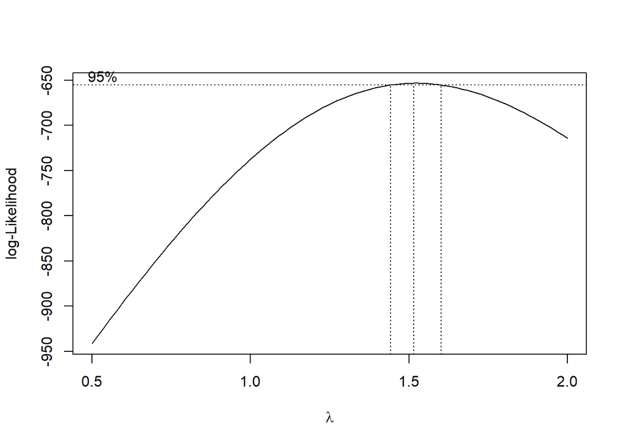

```r
# 1. Bikin indeks sesuai jumlah observasi data train (816 data)
index <- seq(1:length(train.ts))

# 2. Plot Box-Cox
bc <- boxcox(train.ts ~ index, lambda = seq(0.5, 2, by = 0.1))
```

```r
# 3. Nilai lambda optimum (rounded)
lambda_opt <- bc$x[which.max(bc$y)]
lambda_opt
```

```
## [1] 1.515152
```

```r
# 4. Selang kepercayaan 95% untuk lambda
ci_lambda <- bc$x[bc$y > max(bc$y) - 0.5 * qchisq(0.95, df = 1)]

# Batas bawah dan batas atas
ci_lower <- min(ci_lambda)
ci_upper <- max(ci_lambda)
c(Batas_Bawah = ci_lower, Batas_Atas = ci_upper)
```

```
## Batas_Bawah  Batas_Atas
##    1.454545    1.590909
```

Pemeriksaan stasioneritas dalam ragam (varians) dilakukan menggunakan pengujian **Box-Cox** pada data latih (*train set*). Hasil analisis diperlihatkan pada plot Box-Cox serta parameter yang diperoleh sebagai berikut:

- **Nilai Lambda Optimum (**$\hat{\lambda}$) : $1,515$
- **Selang Kepercayaan 95%** : $[1,454 \ ;\ 1,591]$

**Interpretasi Plot & Hasil Pengujian:**

Berdasarkan batas selang kepercayaan $95\%$ (daerah di atas garis horizontal putus-putus pada plot), diperoleh rentang nilai $\lambda$ antara $1,454$ hingga $1,591$.

Karena selang kepercayaan $95\%$ tersebut **tidak memuat nilai** $1$ ($\lambda = 1 \notin [1,454 \ ;\ 1,591]$), maka dapat disimpulkan bahwa data latih **belum stasioner dalam ragam**.

## Penanganan Ketidakstasioneran Data

### Tidak Stasioner dalam Rataan

#### Differencing

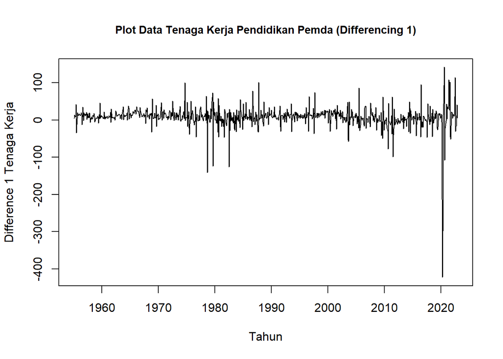

```r
# Differencing pertama langsung dari data train murni
train.diff <- diff(train.ts, differences = 1)

par(mar = c(5, 4, 4, 2) + 0.1)
plot.ts(train.diff,
        lty = 1,
        xlab = "Tahun",
        ylab = "Difference 1 Tenaga Kerja",
        main = "Plot Data Tenaga Kerja Pendidikan Pemda (Differencing 1)",
        cex.main = 0.9)
```

Secara visual, terlihat bahwa data stasioner dalam rataan. Akan tetapi, terdapat nilai ekstrem (outlier) di sekitar tahun 2020. Stasioneritas dalam rataan ini perlu diverifikasi menggunakan uji ADF.

#### Plot ACF

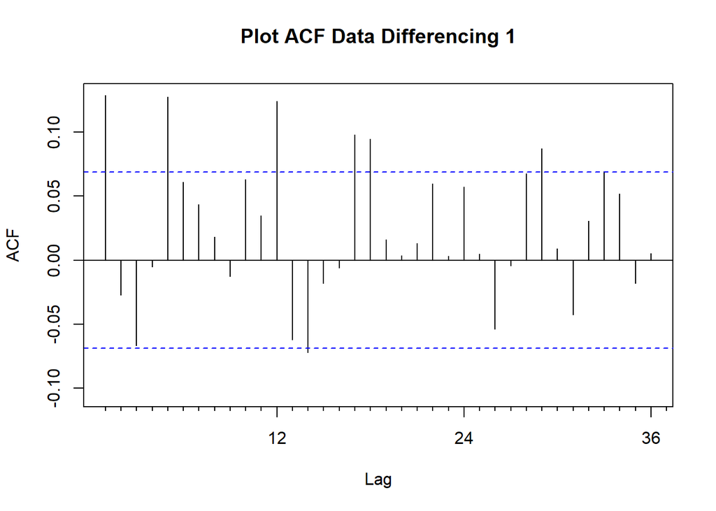

```r
Acf(train.diff, lag.max = 36, main = "Plot ACF Data Differencing 1")
```

Berdasarkan plot ACF dari data latih hasil *differencing* pertama ($d=1$), diperoleh beberapa poin analisis sebagai berikut:

- **Pola Cut Off**: Terlihat adanya *spike* (lonjakan) yang signifikan dan keluar dari garis batas signifikansi $95\%$ pada **Lag 1**. Setelah Lag 1, nilai korelasi pada lag-lag awal berikutnya (Lag 2, 3, dan 4) mengalami penurunan drastis (*cuts off*) dan berada di dalam batas garis biru.
- **Identifikasi Orde MA (**$q$): Sifat plot ACF yang mengalami *cuts off* setelah Lag 1 mengindikasikan bahwa komponen *Moving Average* yang sesuai untuk data ini adalah **MA(1)** atau nilai $q = 1$.

#### Uji ADF

```r
tseries::adf.test(train.diff)
```

```
##
##  Augmented Dickey-Fuller Test
##
## data:  train.diff
## Dickey-Fuller = -7.9887, Lag order = 9, p-value = 0.01
## alternative hypothesis: stationary
```

- $H_0$ : Data memiliki akar unit / *unit root* (Data **tidak stasioner**).
- $H_1$ : Data tidak memiliki akar unit / *unit root* (Data **stasioner**).

Karena $p\text{-value} = 0.01$, maka $p\text{-value} < \alpha$ ($0,05$). Artinya, hipotesis nol ditolak, sehingga terdapat cukup bukti bahwa data stasioner dalam rataan.

### Tidak Stasioner dalam Ragam

#### Box-Cox

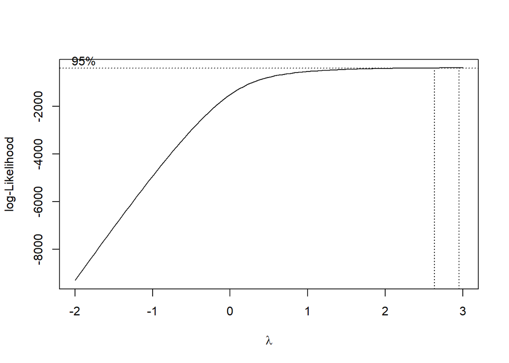

```r
# 1. Indeks sesuai panjang data differencing (815 data)
index_diff <- seq(1:length(train.diff))

# 2. Shifting data agar tidak negatif
min_val <- min(train.diff)
if (min_val <= 0) {
  c <- abs(min_val) + 1
  train.diff_shifted <- train.diff + c
} else {
  train.diff_shifted <- train.diff
}

# 3. Plot Box-Cox dengan rentang lambda yang lebih luas (-2 sampai 3)
bc_diff <- boxcox(train.diff_shifted ~ index_diff, lambda = seq(-2, 3, by = 0.1))
```

```r
# 4. Nilai lambda optimum
lambda_opt_diff <- bc_diff$x[which.max(bc_diff$y)]
print(paste("Lambda optimum setelah diff:", lambda_opt_diff))
```

```
## [1] "Lambda optimum setelah diff: 2.94949494949495"
```

```r
# 5. Selang kepercayaan 95% untuk lambda
ci_lambda_diff <- bc_diff$x[bc_diff$y > max(bc_diff$y) - 0.5 * qchisq(0.95, df = 1)]

# Batas bawah dan batas atas
ci_lower_diff <- min(ci_lambda_diff)
ci_upper_diff <- max(ci_lambda_diff)
c(Batas_Bawah = ci_lower_diff, Batas_Atas = ci_upper_diff)
```

```
## Batas_Bawah  Batas_Atas
##    2.646465    3.000000
```

**Penyebab & Evaluasi Metodologis:**

**Kesimpulan:**

Berdasarkan pertimbangan visual dan karakteristik *outlier* akibat krisis global COVID-19, data hasil *diferensiasi* pertama ($d=1$) disimpulkan **telah memenuhi asumsi kestasioneran ragam secara praktis** dan tidak memerlukan transformasi Box-Cox lanjutan.

## Identifikasi Model

### Plot ACF

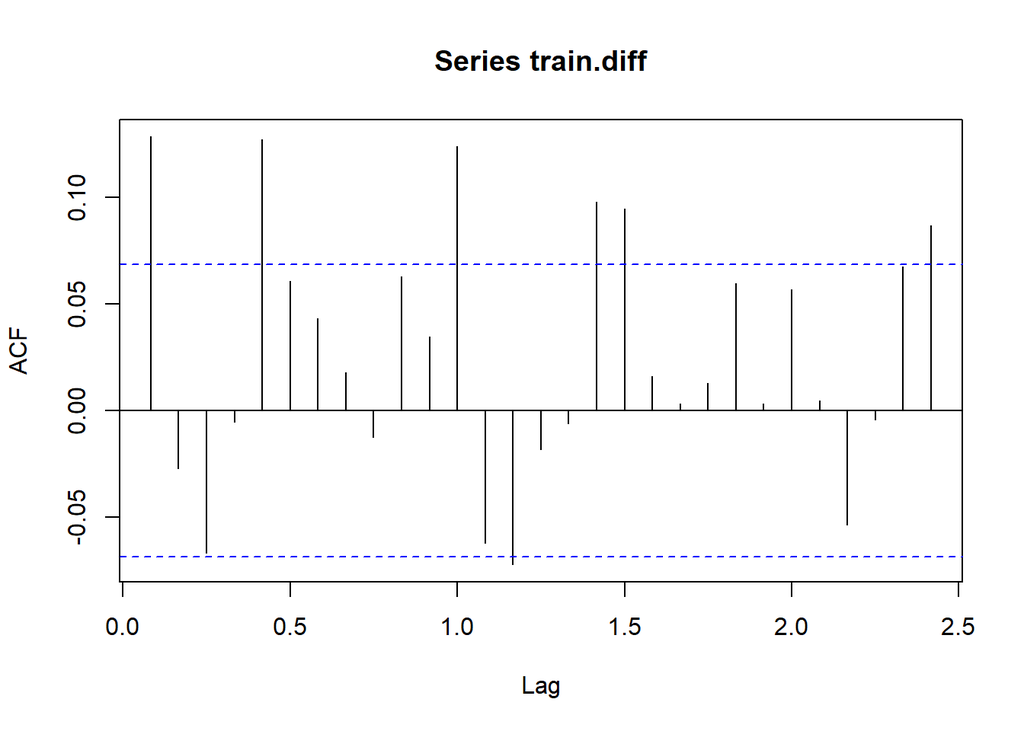

```r
acf(train.diff)
```

### Plot PACF

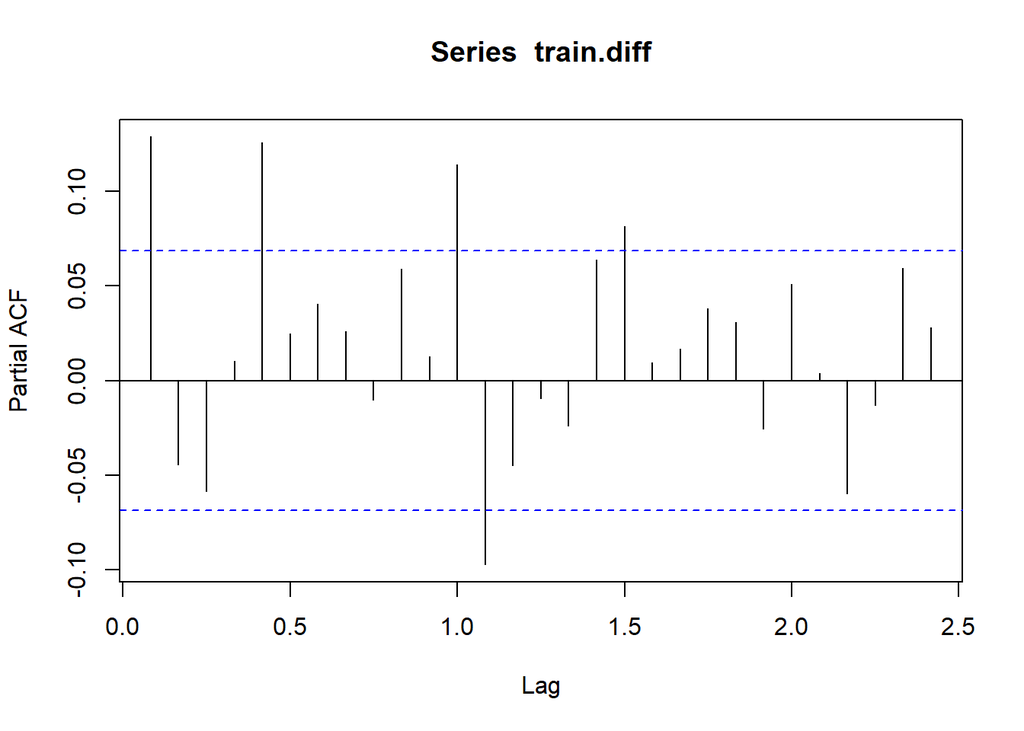

```r
pacf(train.diff)
```

Berdasarkan hasil visualisasi plot Autocorrelation Function (ACF) dan Partial Autocorrelation Function (PACF) pada data latih pasca-diferensiasi pertama ($d=1$), diperoleh identifikasi pola sebagai berikut:

- **Plot PACF**: Menunjukkan adanya lonjakan (*spike*) yang signifikan pada **Lag 1** dan mengalami *cuts off* pada lag-lag awal berikutnya. Pola ini mengindikasikan keberadaan komponen *Autoregressive* orde satu atau **AR(1)** ($p=1$).
- **Plot ACF**: Menunjukkan *spike* signifikan pada **Lag 1** yang kemudian langsung terputus (*cuts off*), mengindikasikan keberadaan komponen *Moving Average* orde satu atau **MA(1)** ($q=1$).

Berdasarkan pola grafik fungsi autokorelasi tersebut, disusulkan 3 kandidat model ARIMA non-musiman untuk diestimasi:

1. **ARIMA(1,1,0)**
2. **ARIMA(0,1,1)**
3. **ARIMA(1,1,1)**

**Catatan Analisis:** Adanya gejolak struktural (*shock*) ekstrem pada era pandemi COVID-19 (2020–2021) memberikan variansi sisaan yang cukup besar pada deret waktu. Meski demikian, ketiga kandidat model ARIMA di atas tetap digunakan sebagai model statistik dasar (*baseline*) sesuai dengan cakupan metodologi Box-Jenkins klasik.

### Plot EACF

```r
eacf(train.diff)
```

```
## AR/MA
##   0 1 2 3 4 5 6 7 8 9 10 11 12 13
## 0 x o o o x o o o o o o  x  o  x
## 1 x o o o x o o o o o o  x  x  o
## 2 x x o o x x o o o o o  x  x  o
## 3 x x x o x o o o o o o  x  x  o
## 4 x x x x x o o o o o o  x  o  o
## 5 x x x x x o o o o o o  x  o  o
## 6 x x x o x o o o o o o  o  x  o
## 7 x x x o o x x o o o o  o  x  o
```

Pengidentifikasian orde model ARIMA tentatif dilakukan dengan mengamati pola segitiga nol (*triangle of zeros* / simbol `o`) pada tabel *Extended Autocorrelation Function* (EACF).

Berdasarkan matriks EACF: * Sudut kiri atas (*top-left vertex*) dari segitiga nilai non-signifikan (`o`) berada pada koordinat **AR = 0** dan **MA = 1**. * Pola segitiga nol yang stabil juga terbentuk pada koordinat **AR = 1** dan **MA = 1**.

Mengingat data telah di-*difference* sebanyak satu kali ($d=1$), maka kandidat model ARIMA tentatif yang diperoleh dari metode EACF adalah:

1. **ARIMA(0,1,1)** (Model paling hemat parameter / *parsimonious*)
2. **ARIMA(1,1,1)**
3. **ARIMA(0,1,2)**

Hasil EACF ini memperkuat temuan dari plot ACF dan PACF sebelumnya yang mengarah pada kandidat utama **ARIMA(0,1,1)** dan **ARIMA(1,1,1)**.

## Pendugaan Parameter Model Tentatif

### ARIMA(0,1,1)

```r
model1.da=Arima(train.diff, order=c(0,1,1),method="ML")
summary(model1.da)
```

```
## Series: train.diff
## ARIMA(0,1,1)
##
## Coefficients:
##           ma1
##       -0.9828
## s.e.   0.0079
##
## sigma^2 = 849.6:  log likelihood = -3901.31
## AIC=7806.63   AICc=7806.64   BIC=7816.03
##
## Training set error measures:
##                      ME     RMSE      MAE  MPE MAPE      MASE      ACF1
## Training set -0.5783536 29.11169 14.73023 -Inf  Inf 0.7172363 0.1035417
```

```r
lmtest::coeftest(model1.da)
```

```
##
## z test of coefficients:
##
##       Estimate Std. Error z value  Pr(>|z|)
## ma1 -0.9827979  0.0078733 -124.83 < 2.2e-16 ***
## ---
## Signif. codes:  0 '***' 0.001 '**' 0.01 '*' 0.05 '.' 0.1 ' ' 1
```

### ARIMA(1,1,1)

```r
model2.da=Arima(train.diff, order=c(1,1,1),method="ML")
summary(model2.da)
```

```
## Series: train.diff
## ARIMA(1,1,1)
##
## Coefficients:
##          ar1      ma1
##       0.1089  -0.9871
## s.e.  0.0355   0.0068
##
## sigma^2 = 840.8:  log likelihood = -3896.63
## AIC=7799.27   AICc=7799.3   BIC=7813.37
##
## Training set error measures:
##                      ME     RMSE      MAE  MPE MAPE      MASE        ACF1
## Training set -0.7090246 28.94352 14.80582 -Inf  Inf 0.7209169 0.005356342
```

```r
lmtest::coeftest(model2.da)
```

```
##
## z test of coefficients:
##
##       Estimate Std. Error   z value  Pr(>|z|)
## ar1  0.1089036  0.0355064    3.0672  0.002161 **
## ma1 -0.9871369  0.0067581 -146.0675 < 2.2e-16 ***
## ---
## Signif. codes:  0 '***' 0.001 '**' 0.01 '*' 0.05 '.' 0.1 ' ' 1
```

### ARIMA(1,1,0)

```r
model3.da=Arima(train.diff, order=c(1,1,0),method="ML")
summary(model3.da)
```

```
## Series: train.diff
## ARIMA(1,1,0)
##
## Coefficients:
##           ar1
##       -0.4105
## s.e.   0.0320
##
## sigma^2 = 1244:  log likelihood = -4055.01
## AIC=8114.03   AICc=8114.04   BIC=8123.43
##
## Training set error measures:
##                      ME     RMSE      MAE  MPE MAPE     MASE       ACF1
## Training set 0.01847282 35.23087 18.34106 -Inf  Inf 0.893053 -0.1164658
```

```r
lmtest::coeftest(model3.da)
```

```
##
## z test of coefficients:
##
##      Estimate Std. Error z value  Pr(>|z|)
## ar1 -0.410451   0.031959 -12.843 < 2.2e-16 ***
## ---
## Signif. codes:  0 '***' 0.001 '**' 0.01 '*' 0.05 '.' 0.1 ' ' 1
```